# Homework 5

Matthew Swanson

20191126

1. The data set `FishMercury` contains mercury levels (parts per million) for 30 fish caught in lakes in Minnesota.
1. Create a histogram or boxplot of the data. What do you observe?

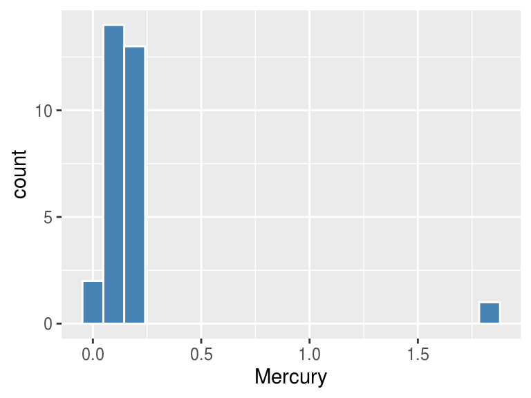

```r
ggplot(data = FishMercury, aes(x = Mercury)) +
  geom_histogram(bins = 20, fill = "steelblue", color = "white")
```

2. Bootstrap the mean and record the bootstrap standard error and the 95% bootstrap percentile interval.

```r
set.seed(888)
n <- length(FishMercury$Mercury) # This is the original sample size

B <- 10000  # The number of bootstrap samples
boot_Mean <- numeric(B) # A vector to store bootstrap menas from the bootstrap samples

for (i in 1:B){
  x <- sample(FishMercury$Mercury, size = n, replace = TRUE) # Here n is the size of your bootstrap sample
  boot_Mean[i] <- mean(x)
}

mean(boot_Mean) # This is the mean of the bootstrap means - so the center of the bootstrap distribution
```

```
## [1] 0.1819197
```

```r
sd(boot_Mean) # This is the standard error of the bootstrap distribution
```

```
## [1] 0.05775204
```

```r
quantile(boot_Mean, probs = c(0.025,0.975))
```

```
##      2.5%     97.5%
## 0.1120000 0.3069692
```

> $\bar{X} = 0.1819197$

> $\sigma_X = 0.05775204$

> We are 95% confident that the mean mercury concentration in fish is between the values of $0.112$ and $0.3069692$.
3. Remove the outlier and bootstrap the mean of the remaining data. Record the bootstrap standard error and the 95% bootstrap percentile interval.

```r
FishMercuryNoOutlier = FishMercury[-c(1),]
head(FishMercuryNoOutlier)
```

```
## [1] 0.160 0.088 0.160 0.145 0.099 0.101
```

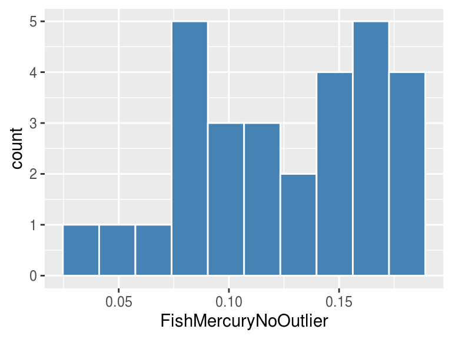

```r
ggplot(data = data.frame(FishMercuryNoOutlier), aes(x = FishMercuryNoOutlier)) +
  geom_histogram(bins = 10, fill = "steelblue", color = "white")
```

```r
set.seed(888)
n <- length(FishMercuryNoOutlier) # This is the original sample size
B <- 10000  # The number of bootstrap samples
boot_Mean <- numeric(B) # A vector to store bootstrap menas from the bootstrap samples
for (i in 1:B){
  x <- sample(FishMercuryNoOutlier, size = n, replace = TRUE) # Here n is the size of your bootstrap sample
  boot_Mean[i] <- mean(x)
}
mean(boot_Mean) # This is the mean of the bootstrap means - so the center of the bootstrap distribution
```

```
## [1] 0.123513
```

```r
sd(boot_Mean) # This is the standard error of the bootstrap distribution
```

```
## [1] 0.007774483
```

```r
quantile(boot_Mean, probs = c(0.025,0.975))
```

```
##      2.5%     97.5%
## 0.1079655 0.1385172
```

> $\bar{X} = 0.123513$

> $\sigma_X = 0.007774483$

> We are 95% confident that the mean mercury concentration in fish without outliers is between the values of $0.1079655$ and $0.1385172$.
4. What effect did removing the outlier have on the bootstrap distribution, in particular, the standard error?

> By removing the outlier from the distribution, the mean decreased and the standard error decreased dramatically ($0.05775204$ with the outlier and $0.007774483$ without).
2. In section 3.3, we performed a permutation test to determine if men and women consumed, on average, different amounts of hot wings. Here, we do this using bootstraps.
1. Bootstrap the difference in means and describe the bootstrap distribution.

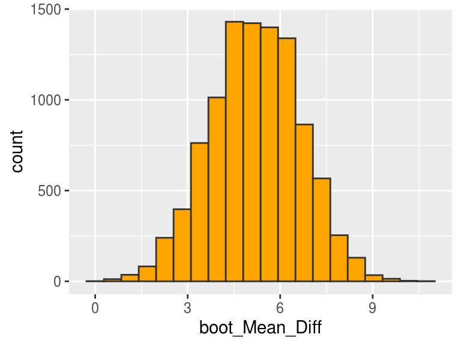

```r
BeerwingsMale = Beerwings %>% filter(Gender == "M")
BeerwingsFemale = Beerwings %>% filter(Gender == "F")

set.seed(888)
nm = nrow(BeerwingsMale)
nf = nrow(BeerwingsFemale)
B = 10000
boot_Mean_Diff = numeric(B)
for (i in 1:B) {
    m <- sample(BeerwingsMale$Hotwings, size = nm, replace = TRUE)
    f <- sample(BeerwingsFemale$Hotwings, size = nf, replace = TRUE)
    boot_Mean_Diff[i] <- mean(m) - mean(f) #male - female
}

ggplot(data = data.frame(boot_Mean_Diff), aes(x = boot_Mean_Diff)) +
  geom_histogram(bins = 20, fill = "orange", color = "grey20")
```

```r
mean(boot_Mean_Diff)
```

```
## [1] 5.19644
```

```r
sd(boot_Mean_Diff)
```

```
## [1] 1.448123
```

> The bootstrap distribution of the difference of the means is normally distributed with a mean of $5.19644$ and a standard error of $1.448123$.
2. Find a 95% bootstrap percentile confidence interval for the difference of means and give a sentence interpreting this interval.

```r
quantile(boot_Mean_Diff, probs = c(0.025,0.975))
```

```
##     2.5%    97.5%
## 2.333333 8.000000
```

> We are 95% confident that men consume, on average, between $2.33$ and $8$ more hotwings than women.
3. Import the data from `Girls2004` (see Section 1.2).
1. Use `skim()` to obtain summary statistics on the weight of baby girls born in Wyoming and Alaska.

```r
Girls2004 %>% skim()
```

Table 1: Data summary

| Name | Piped data |
| --- | --- |
| Number of rows | 80 |
| Number of columns | 6 |
| _______________________ |  |
| Column type frequency: |  |
| factor | 3 |
| numeric | 3 |
| ________________________ |  |
| Group variables | None |

**Variable type: factor**

| skim_variable | n_missing | complete_rate | ordered | n_unique | top_counts |
| --- | --- | --- | --- | --- | --- |
| State | 0 | 1 | FALSE | 2 | AK: 40, WY: 40 |
| MothersAge | 0 | 1 | FALSE | 6 | 20-: 29, 25-: 22, 30-: 15, 15-: 6 |
| Smoker | 0 | 1 | FALSE | 2 | No: 69, Yes: 11 |

**Variable type: numeric**

| skim_variable | n_missing | complete_rate | mean | sd | p0 | p25 | p50 | p75 | p100 | hist |
| --- | --- | --- | --- | --- | --- | --- | --- | --- | --- | --- |
| ID | 0 | 1 | 40.50 | 23.24 | 1 | 20.75 | 40.5 | 60.25 | 80 | ▇▇▇▇▇ |
| Weight | 0 | 1 | 3362.12 | 525.24 | 2182 | 3076.25 | 3331.0 | 3709.00 | 4592 | ▂▃▇▃▂ |
| Gestation | 0 | 1 | 39.14 | 1.22 | 37 | 38.00 | 39.0 | 40.00 | 42 | ▆▇▅▃▁ |

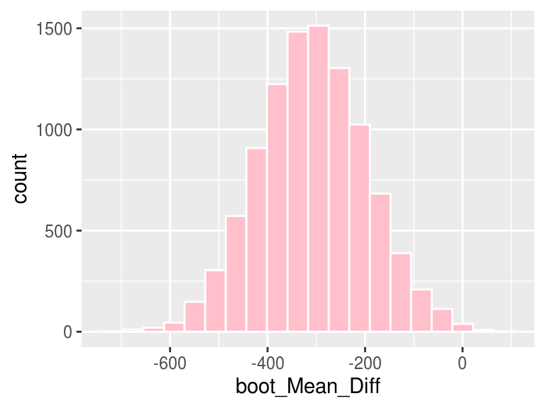

```r
GirlsWY = Girls2004 %>% filter(State == "WY")
GirlsAK = Girls2004 %>% filter(State == "AK")

set.seed(888)
nwy = nrow(GirlsWY)
nak = nrow(GirlsAK)
B = 10000
boot_Mean_Diff = numeric(B)
for (i in 1:B) {
    wy <- sample(GirlsWY$Weight, size = nwy, replace = TRUE)
    ak <- sample(GirlsAK$Weight, size = nak, replace = TRUE)
    boot_Mean_Diff[i] <- mean(wy) - mean(ak) #wyoming - alaska
}

ggplot(data = data.frame(boot_Mean_Diff), aes(x = boot_Mean_Diff)) +
  geom_histogram(bins = 20, fill = "pink", color = "white")
```

```r
mean(boot_Mean_Diff)
```

```
## [1] -307.6122
```

```r
sd(boot_Mean_Diff)
```

```
## [1] 111.1971
```

```r
quantile(boot_Mean_Diff, probs = c(0.025,0.975))
```

```
##       2.5%      97.5%
## -523.12688  -84.87063
```

> The bootstrap distribution of the difference of the means is normally distributed with a mean of $-307.6122$ and a standard error of $111.1971$.

> $\bar{X} = -307.6122$

> $\sigma_X = 111.1971$

> We are 95% confident that Wyoming girl babies are between $84.87063$ and $523.12688$ grams lighter than Alaska girl babies.
3. What is the bootstrap estimate of the bias?

```r
bootMeanDiff = mean(boot_Mean_Diff)
ogMeanDiff = (mean(GirlsWY$Weight) - mean(GirlsAK$Weight))
Bias = bootMeanDiff - ogMeanDiff
Bias
```

```
## [1] 0.8378375
```

> $Bias = -307.6122 - (-308.45) = 0.8378375$
4. Do chocolate and vanilla ice creams have the same number of calories? The data set `IceCream` contains calorie information for a sample of brands of chocolate and vanilla ice cream. Use the bootstrap to determine whether or not there is a difference in the mean number of calories.

```r
Chocolate = IceCream$ChocolateCalories
Vanilla = IceCream$VanillaCalories

CalorieDiff = Chocolate - Vanilla

set.seed(888)
n = length(CalorieDiff)
B = 10000
boot_Mean_Diff = numeric(B)

for (i in 1:B) {
    samp = sample(CalorieDiff, size = n, replace = TRUE)
    boot_Mean_Diff[i] = mean(samp)
}

quantile(boot_Mean_Diff, probs = c(0.025,0.975))
```

```
##      2.5%     97.5%
##  3.435897 11.435897
```

> We are 95% confident that the mean calories in chocolate ice cream is between $3.435897$ and $11.435897$ calories higher than the mean number of calories in vanilla ice cream.